## Milestone Report: Data Science Specialization Fall 2014 Capstone

by: Ryan M. Swartz

### Introduction

This report summarizes the effort, so far, to build a model capable of predicting the next word a user intends as they type a message on a mobile device. This model could form the basis of an productivity application that greatly increases the speed with which a user composes messages.

### Data Operations

To provide a history of the data used in this process, the following snippet of code defines the data ingestion process after download and extraction of the training data from the Coursera website to a working directory. This code also contains some basic steps to clean the data based upon warnings present when ingesting.

```r
## load all libraries needed for these processes
library(tm)
library(slam)
library(ggplot2)
library(plyr)
library(stringi)
## import Twitter data
twitter.con <- file(paste0(getwd(), "/final/en_US/en_US.twitter.txt"), "r")
twitter.full <- readLines(twitter.con)
close(twitter.con)
# remove results with embedded nulls
twitter.full <- twitter.full[-c(167155, 268547, 1274086, 1759032)]
## import Blogs data
blogs.con <- file(paste0(getwd(), "/final/en_US/en_US.blogs.txt"), "r")
blogs.full <- readLines(blogs.con)
close(blogs.con)
## import News data
news.con <- file(paste0(getwd(), "/final/en_US/en_US.news.txt"), "r")
news.full <- readLines(news.con)
close(news.con)
## remove incomplete result
news.full <- news.full[-77259]
```

Before digging into this content, below are some basic statistics on each of these data sources to provide some context and idea of the likely processing of working with this data.

```r
## stats on Twitter data
stri_stats_general(twitter.full)
```

```
##       Lines LinesNEmpty       Chars CharsNWhite
##     2360144     2360144   162384594   134370673
```

```r
stri_stats_latex(twitter.full)
```

```
##     CharsWord CharsCmdEnvir    CharsWhite         Words          Cmds
##     125769132          3033      36047853      30578850           963
##        Envirs
##             0
```

```r
## stats on blogs data
stri_stats_general(blogs.full)
```

```
##       Lines LinesNEmpty       Chars CharsNWhite
##      899288      899288   208361438   171926076
```

```r
stri_stats_latex(blogs.full)
```

```
##     CharsWord CharsCmdEnvir    CharsWhite         Words          Cmds
##     163325412             9      43302825      37865888             3
##        Envirs
##             0
```

```r
## stats on news data
stri_stats_general(news.full)
```

```
##       Lines LinesNEmpty       Chars CharsNWhite
##       77258       77258    15683692    13116978
```

```r
stri_stats_latex(news.full)
```

```
##     CharsWord CharsCmdEnvir    CharsWhite         Words          Cmds
##      12502896             0       3114359       2665729             0
##        Envirs
##             0
```

[output not shown]

Blogs, with their longer form provide the largest amount of data, but Twitter provides a greater variety of content based upon the Words per Line measure. With this consideration and the purpose of the application - to enable faster message creation on mobile devices - I chose to work with the Twitter data only for the exploratory analysis. This decision is also based upon the assumption that Twitter messages will likely be the closest style of writing a user is trying to emulate.

Due to memory limitations, I performed this analysis on a random 10% sample of the provided Twitter data as this volume would still be significant enough for some exploratory analysis. To prepare this sample, I also performed a series of pre-processing steps in order:

1. Remove punctuation: this is not something I’m looking to predict
2. Change all terms to lower case: for analysis and prediction, this will enable greater efficiency; to include capitalization in the final model, I can institute simple rules after prediction
3. Stop word removal: to prevent offense to the user, I’ve scrubbed the sample data of swear words according to George Carlin’s “Seven Words You Can’t Say on Television” comedy routine (the code for this step won’t be shown to prevent offense)
4. Whitespace removal: this final step in the pre-processing is a clean-up action to remove extra spaces in the text (not the single spaces between words)

*Sampling*

```r
twitter.sample <- sample(twitter.full, length(twitter.full) * 0.10,
                         replace = FALSE)
twitter.corpus <- Corpus(VectorSource(twitter.sample))
```

*Remove Punctuation*

```r
twitter.corpus <- tm_map(twitter.corpus, removePunctuation)
```

*Change to Lower Case*

```r
twitter.corpus <- tm_map(twitter.corpus, content_transformer(tolower))
```

*Stop Word Removal*

Note: code omitted as it contains offensive language.

*Whitespace Removal*

```r
twitter.corpus <- tm_map(twitter.corpus, stripWhitespace)
```

### Exploratory Data Analysis

With the initial processing steps complete, I will focus on the sample data and use tools from the `tm` package to get some summary information from the Twitter corpus.

The first step is to turn the data into a `TermDocumentMatrix` - this is a structured table that goes through each entry in the Twitter corpus (i.e., each Tweet) and tabulates what words are used in that Tweet and how many times they are used. Doing this for each document, we are left with a record of all words used in the corpus and their frequency of usage.

```r
twitter.tdm <- TermDocumentMatrix(twitter.corpus)
```

Since the `TermDocumentMatrix` isn’t in form readily available for analysis, the following defines simple transformations of the content to produce an overall count of all the words present in the Twitter sample data and how many times they appear in aggregate.

```r
## aggregate the word counts
twitter.tdm.sum <- rollup(twitter.tdm, 2, na.rm = TRUE, FUN = sum)
## convert to dataframe
twitter.tdm.sum <- as.data.frame(as.matrix(twitter.tdm.sum))
## create new variable to track the term, clear row.names, and rename and reorder
## variables
twitter.tdm.sum$Term <- row.names(twitter.tdm.sum)
row.names(twitter.tdm.sum) <- NULL
names(twitter.tdm.sum) <- c("Freq", "Term")
twitter.tdm.sum <- subset(twitter.tdm.sum, select = c("Term", "Freq"))
## sort dataframe by term frequency
twitter.tdm.sum <- arrange(twitter.tdm.sum, -Freq)
```

The following histogram pulls from this data frame to get a sense of the distribution of the amount of occurrences of each word.

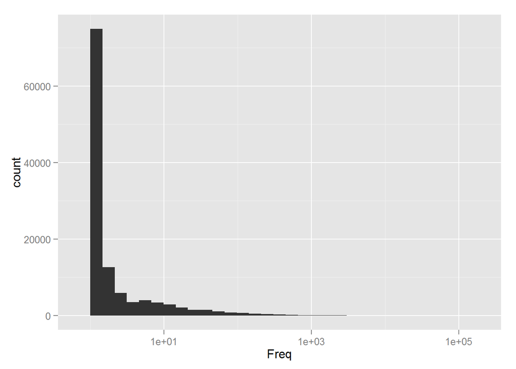

```r
fig.1 <- ggplot(twitter.tdm.sum, aes(x = Freq)) + geom_histogram() + scale_x_log10()
```

Clearly, many of the words in our cropus have a low frequency of occurrence, but there are still a small subset of words that occur quite frequently. The prediction model that results from this project must be able to account for that - pick up on the common words, but also recognize those that infrequently occur.

To focus on the most common words, to start, I’ll add some other metrics tracking relative frequency of occurrence to the data frame for further analysis.

```r
## calculate a running tally of word frequency
twitter.tdm.sum$Run.Sum <- cumsum(twitter.tdm.sum$Freq)
## calculate the term's percentage of all words in the sample
twitter.tdm.sum$Percent <- round((twitter.tdm.sum$Freq /
                                    sum(twitter.tdm.sum$Freq)) * 100, 2)
## calculate a running tally of the percentage
twitter.tdm.sum$Run.Percent <- cumsum(twitter.tdm.sum$Percent)
```

With this data, let’s look a graphical and numeric summary of the ten most frequent words in the Twitter sampple.

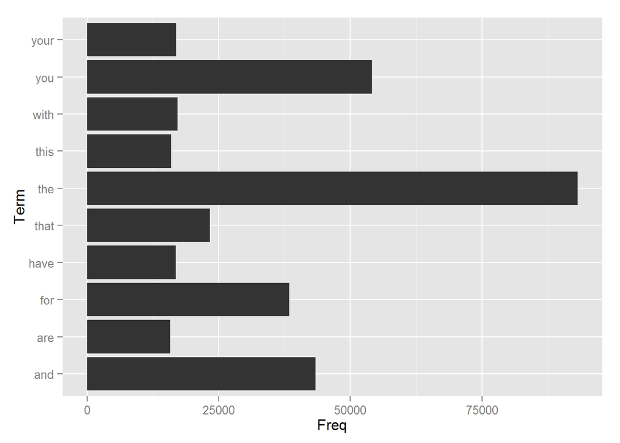

```r
twitter.tdm.sum.ten <- twitter.tdm.sum[1:10, ]
fig.2 <- ggplot(twitter.tdm.sum.ten, aes(x = Term, y = Freq)) +
  geom_bar(stat = "identity") +
  coord_flip()
```

Words like ‘the’, ‘you’, ‘and’, and ‘for’ dominate the counts and represent large portions of the overall word count:

| Word | Count | % of Sample | Running % |
| --- | --- | --- | --- |
| the | 9.316 × 10<sup>4</sup> | 4.08 | 4.08 |
| you | 5.4071 × 10<sup>4</sup> | 2.37 | 6.45 |
| and | 4.3428 × 10<sup>4</sup> | 1.9 | 8.35 |
| for | 3.8348 × 10<sup>4</sup> | 1.68 | 10.03 |
| that | 2.3326 × 10<sup>4</sup> | 1.02 | 11.05 |
| with | 1.7155 × 10<sup>4</sup> | 0.75 | 11.8 |
| your | 1.6881 × 10<sup>4</sup> | 0.74 | 12.54 |
| have | 1.6818 × 10<sup>4</sup> | 0.74 | 13.28 |
| this | 1.5917 × 10<sup>4</sup> | 0.7 | 13.98 |
| are | 1.58 × 10<sup>4</sup> | 0.69 | 14.67 |

Just considering the first ten words alone, we are able to cover almost 15% of our entire sample. However, only considering a small number of words is is not something on which I can rely to build the model - as shown in the histogram, there are a far greater proportion of less frequently occurring words than these most popular ten.

### Next Steps

Through the actions above, I have achieved several goals:

- Obtained corpi of potential training data to construct the prediction model
- Performed initial processing steps to prepare this data for the model building process
- Completed some initial analyses of the data to understand its nature in terms of word frequency and distribution of that frequency

With this as a basis, the next phase of the project will take the following steps to build the desired application to enhance the efficiency of message composition:

- Tokenize the data into discrete portions of text ranging in size from one to as many as five or size words long (i.e., n gram tokenization with n as little as 1 and as large as 5 or 6)
- Utilize machine learning to construct a model that uses the tokenized data as input in understanding the relationships between words to then predict what word a users intends to type next when composing a message
- Test this model’s accuracy and robustness and tune accordingly
- Once satisifed, host the model via a web application for users to experiment and/or utilize for greater message composition efficiency